# HW5-Camilla Zhai

2022-11-16

```r
library(tidymodels)
library(ISLR)
library(ISLR2)
library(tidyverse)
library(dplyr)
library(ggplot2)
library(glmnet)
library(klaR)
library(corrr)
library(corrplot)
library(discrim)
library(poissonreg)
tidymodels_prefer()
#install.packages("janitor") #installing the janitor package
library(janitor) #loading the janitor package
pokemon <- read_csv(file='/Users/weiqizhai/Desktop/Pokemon.csv')
```

Q1:

```r
pokemon <- clean_names(pokemon)
pokemon
```

```
## # A tibble: 800 × 13
##    number name      type_1 type_2 total    hp attack defense sp_atk sp_def speed
##     <dbl> <chr>     <chr>  <chr>  <dbl> <dbl>  <dbl>   <dbl>  <dbl>  <dbl> <dbl>
##  1      1 Bulbasaur Grass  Poison   318    45     49      49     65     65    45
##  2      2 Ivysaur   Grass  Poison   405    60     62      63     80     80    60
##  3      3 Venusaur  Grass  Poison   525    80     82      83    100    100    80
##  4      3 Venusaur… Grass  Poison   625    80    100     123    122    120    80
##  5      4 Charmand… Fire   <NA>     309    39     52      43     60     50    65
##  6      5 Charmele… Fire   <NA>     405    58     64      58     80     65    80
##  7      6 Charizard Fire   Flying   534    78     84      78    109     85   100
##  8      6 Charizar… Fire   Dragon   634    78    130     111    130     85   100
##  9      6 Charizar… Fire   Flying   634    78    104      78    159    115   100
## 10      7 Squirtle  Water  <NA>     314    44     48      65     50     64    43
## # … with 790 more rows, and 2 more variables: generation <dbl>, legendary <lgl>
```

clean_names() function converts all the variable names to lower cases and puts underscores between the gaps, in which it makes all the variable names in the pokemon dataset consistent. This function is useful because it removes all punctuation marks from variable names that are not allowed/supported in R syntax (blank space,period…etc). Simultaneously, the function replaces unsupported punctuation marks with R-supported syntax, such as underscores. Furthermore, the clean_names() function converts all letters in variable names to lower case. All of these actions are designed to eliminate troublesome errors and make data analysis much easier in the future.

Q2:

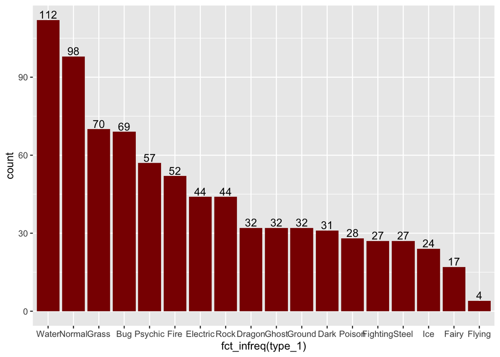

```r
pokemon %>%
  ggplot(aes(fct_infreq(type_1)))+
  geom_bar(fill="darkred")+
  geom_text(aes(label=..count..), stat="count", vjust=-0.2)
```

From the bar chart above, we can see that there are 18 classes. Among 18 pokemon types, “Flying” type has very few pokemon.

```r
pokemon1<-pokemon %>% filter(pokemon$type_1==c("Bug","Fire","Grass","Normal","Water","Psychic"))
pokemon1$type_1 <- factor(pokemon1$type_1)
pokemon1$legendary <- factor(pokemon1$legendary)
```

Q3:

```r
set.seed(2022)
pokemon_split<- initial_split(pokemon1, prop=0.7,strata=type_1)
pokemon_split
```

```
## <Training/Testing/Total>
## <54/28/82>
```

```r
train_set <- training(pokemon_split)
test_set <- testing(pokemon_split)
dim(train_set)  # verify that the training and testing data sets have the desired number of observations
```

```
## [1] 54 13
```

```r
dim(test_set)
```

```
## [1] 28 13
```

```r
pm_fold <- vfold_cv(train_set, v = 5, strata=type_1)
pm_fold
```

```
## #  5-fold cross-validation using stratification
## # A tibble: 5 × 2
##   splits          id
##   <list>          <chr>
## 1 <split [40/14]> Fold1
## 2 <split [42/12]> Fold2
## 3 <split [43/11]> Fold3
## 4 <split [45/9]>  Fold4
## 5 <split [46/8]>  Fold5
```

Stratifying the folds keeps the same class ratio throughout all five folds as it did in the initial dataset, which helps to capture essential population traits in the sample and allows for more accurate future prediction.

Q4:

```r
pokemon_recipe <- recipe(type_1 ~ legendary+generation+sp_atk+attack+speed+
                           defense+hp+sp_def, train_set)%>%
  step_dummy(legendary,generation)%>%
  step_normalize(all_predictors())
```

Q5:

```r
reg_spec <-
  multinom_reg(penalty = tune(), mixture = tune()) %>%
  set_mode("classification") %>%
  set_engine("glmnet")
reg_wf <- workflow() %>% add_recipe(pokemon_recipe) %>%
  add_model(reg_spec)

A_grid <- grid_regular(penalty(range = c(-5, 5)), mixture(range = c(0, 1)),levels = 10)
A_grid
```

```
## # A tibble: 100 × 2
##          penalty mixture
##            <dbl>   <dbl>
##  1      0.00001        0
##  2      0.000129       0
##  3      0.00167        0
##  4      0.0215         0
##  5      0.278          0
##  6      3.59           0
##  7     46.4            0
##  8    599.             0
##  9   7743.             0
## 10 100000              0
## # … with 90 more rows
```

Q6:

```r
tune_res <- tune_grid(
  reg_wf,
  resamples = pm_fold,
  grid = A_grid
)
```

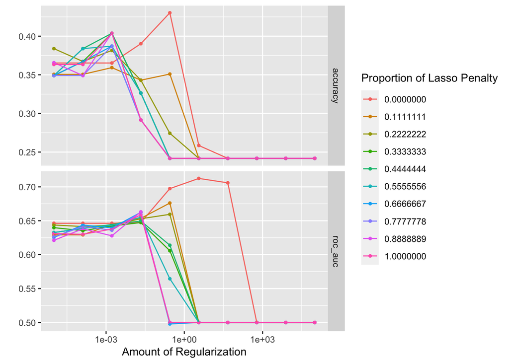

```r
autoplot(tune_res)
```

If we ignore the proportion of lasso penalty, we can see that the roc auc and accuracy increase as the value of lamda increases; after a certain value of lamda, the roc auc and accuracy begin to decrease and continue to decrease as the value of lamda increases. When we consider the lasso penalty proportion, we can see from the plot that smaller values of penalty and mixture produce better roc auc and accuracy.

Q7:

```r
best_penalty <- select_best(tune_res, metric = "roc_auc")
best_penalty
```

```
## # A tibble: 1 × 3
##   penalty mixture .config
##     <dbl>   <dbl> <chr>
## 1    3.59       0 Preprocessor1_Model006
```

```r
final1 <- finalize_workflow(reg_wf, best_penalty)
final_fit <- fit(final1, data = train_set)# fitting the model to the training set
test1<- augment(final_fit, new_data = test_set)
acc<- test1%>%accuracy(truth = type_1, estimate =.pred_class)
acc
```

```
## # A tibble: 1 × 3
##   .metric  .estimator .estimate
##   <chr>    <chr>          <dbl>
## 1 accuracy multiclass     0.214
```

The accuracy of this model on the testing set is very low (≈0.2). So its performance on the testing set is bad.

Q8:

```r
test1%>%roc_auc(type_1,.pred_Bug:.pred_Water)
```

```
## # A tibble: 1 × 3
##   .metric .estimator .estimate
##   <chr>   <chr>          <dbl>
## 1 roc_auc hand_till      0.453
```

The overall ROC AUC on the testing set is approximately 0.45.

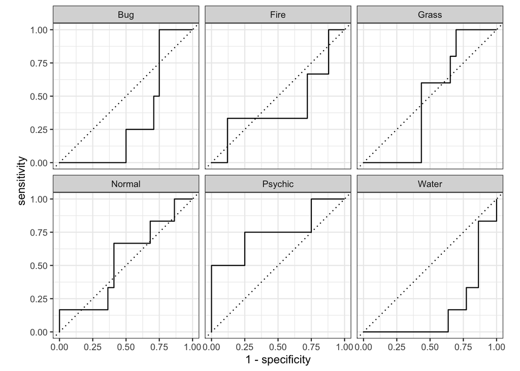

```r
test1 %>% roc_curve(type_1,.pred_Bug:.pred_Water) %>% autoplot()
```

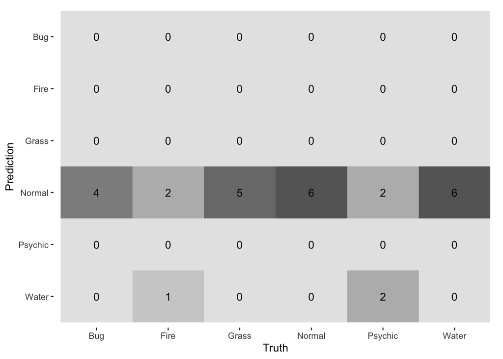

```r
test1 %>% conf_mat(truth = type_1, .pred_class) %>% autoplot(type="heatmap")
```

The overall ROC AUC on the testing set is about 0.45, which is quite low; this indicates that our model performed poorly on the testing set. In addition, the roc curve reveals that our model has no capacity for class separation. The AUC for four Pokemon types (bug, fire, grass, and water) is generally less than 0.5, but only two Pokemon types (normal and psychic) have an AUC more than 0.5. From the confusion matrix’s heat map, we can also tell that the model performs best when predicting the type of normal, performs worst when predicting the type of water, and the majority of the model’s predictions are “normal,” indicating that this model lacks predictive ability. This could be due to underfitting.